# Predicting Diabetes with Decision Trees and Random Forests

Cliff Lee

2023-10-17

### Abstract

In the article, “The GOOD, The BAD & The UGLY of Using Decision Trees” ([3]), the author gives an overview of decision trees; how they are an easily understood tool for strategic thinking and decision making. However, the downsides of decision trees include:

- Repeating logic in multiple nodes - if one repeating logic is changed, it has to be changed everywhere else too
- Some trees can be too complicated with too many levels
- Sensitive to data - little changes to data can change the tree a lot

To study decision trees and random forest models, I chose a diabetes dataset from Kaggle ([1]). It has several continuous health related independent variables. The dependent, categorical variable is ‘outcome’ which indicates whether a given patient has diabetes. After balancing the classes with respect to the outcome variable, I created two decision trees using different predictors; they both had accuracy rates in the mid 70% range; I later “pruned” ([2])the trees to improve the visualization. On the other hand, a random forest mode’s accuracy was in 90% range.

Even though, the random forest model had a higher accuracy it was not as accessible. There is no visualization graph that explains how the model works as it’s blackbox of ensemble learners. We can only visualize its accuracy as it builds more decision trees. However, because it’s composed of many trees, random forests are more resilient to data changes.

References:

[1] https://www.kaggle.com/datasets/willianoliveiragibin/diabetesdataanslysis  
[2] https://dzone.com/articles/decision-trees-and-pruning-in-r  
[3] https://decizone.com/blog/the-good-the-bad-the-ugly-of-using-decision-trees

### Exploratory Data Analysis

The data set has eight continuous variables and one categorical dependent variable (outcome). From the summary output, we see there is no missing data and the diabetes pedigree function (DPF) feature appears to be normalized.

```
##   Pregnancies        Glucose      BloodPressure    SkinThickness
##  Min.   : 0.000   Min.   :  0.0   Min.   :  0.00   Min.   : 0.00
##  1st Qu.: 1.000   1st Qu.: 99.0   1st Qu.: 62.00   1st Qu.: 0.00
##  Median : 3.000   Median :117.0   Median : 72.00   Median :23.00
##  Mean   : 3.845   Mean   :120.9   Mean   : 69.11   Mean   :20.54
##  3rd Qu.: 6.000   3rd Qu.:140.2   3rd Qu.: 80.00   3rd Qu.:32.00
##  Max.   :17.000   Max.   :199.0   Max.   :122.00   Max.   :99.00
##     Insulin           BMI        DiabetesPedigreeFunction      Age
##  Min.   :  0.0   Min.   : 0.00   Min.   :0.0780           Min.   :21.00
##  1st Qu.:  0.0   1st Qu.:27.30   1st Qu.:0.2437           1st Qu.:24.00
##  Median : 30.5   Median :32.00   Median :0.3725           Median :29.00
##  Mean   : 79.8   Mean   :31.99   Mean   :0.4719           Mean   :33.24
##  3rd Qu.:127.2   3rd Qu.:36.60   3rd Qu.:0.6262           3rd Qu.:41.00
##  Max.   :846.0   Max.   :67.10   Max.   :2.4200           Max.   :81.00
##  Outcome
##  1:268
##  0:500
##
##
##
##
```

The outcome feature is imbalanced (268 versus 500) so we’ll have to resample the classes to balance the classes before training.

```
##   1   0
## 268 500
```

# Continous variable distributions

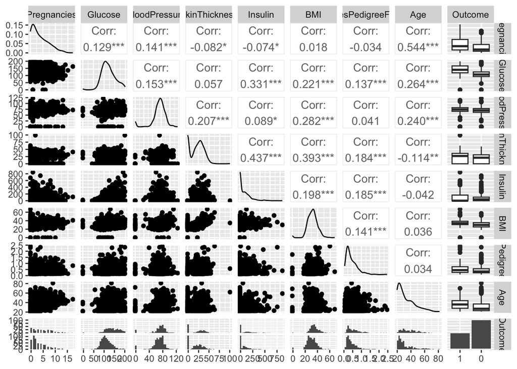

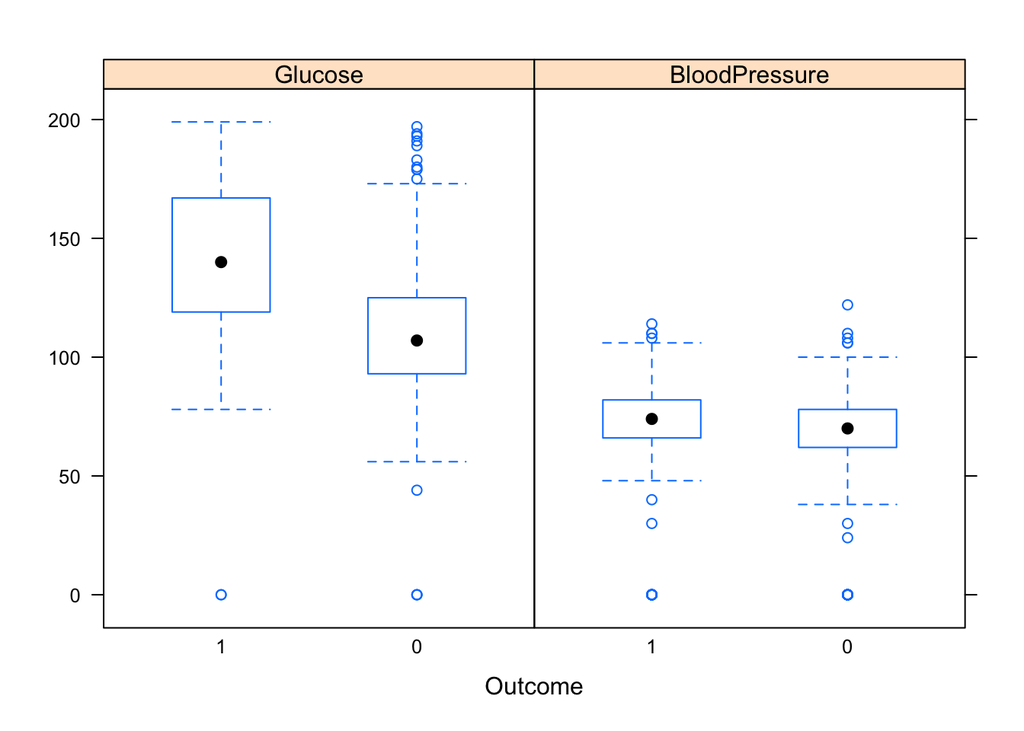

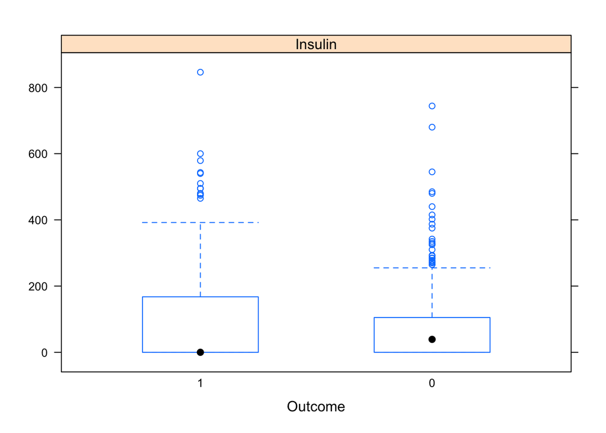

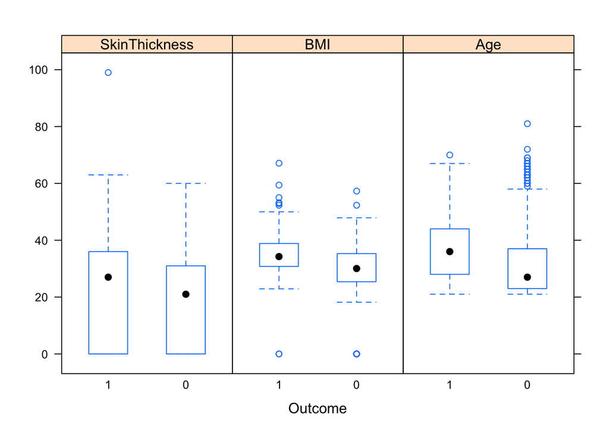

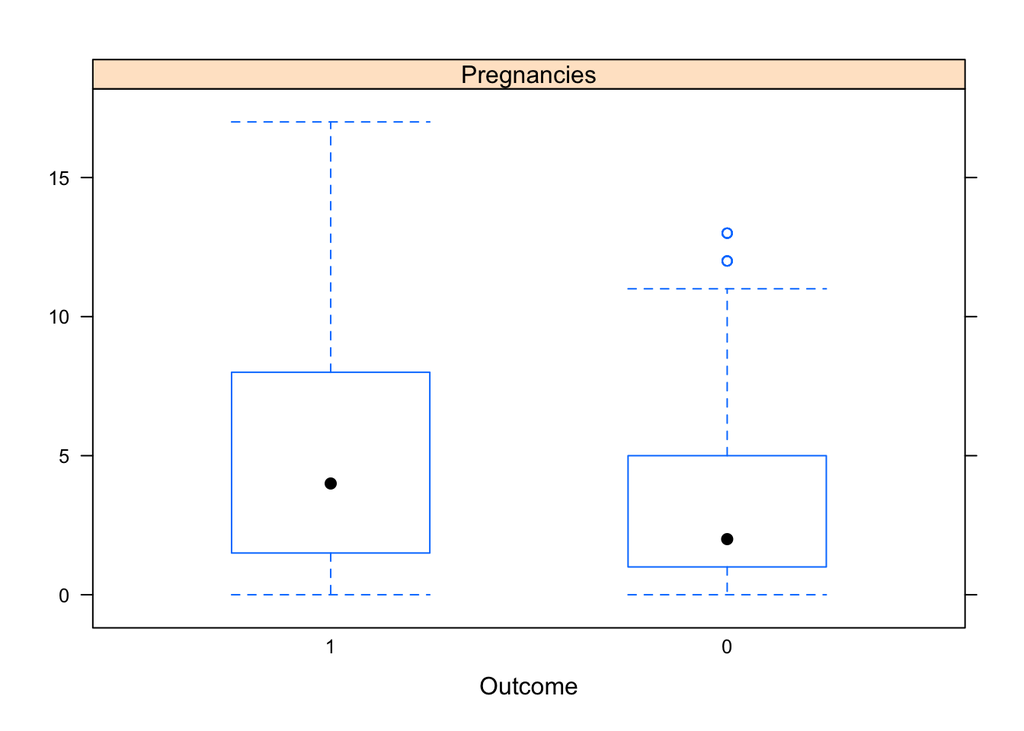

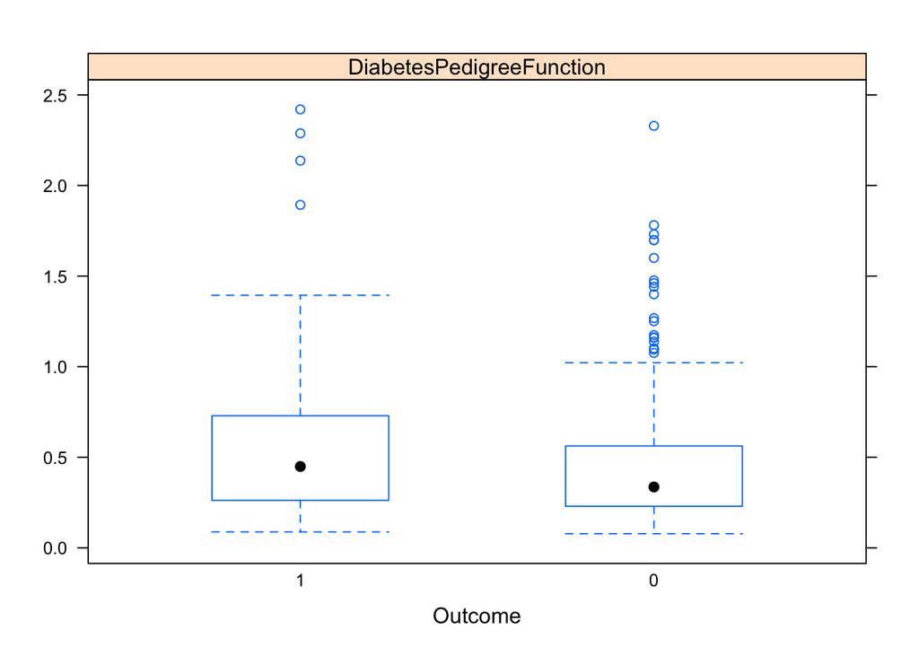

### Balancing The Outcome Variable

As noted, we have to balance the data set with respect to the outcome variable using the SMOTE function. We end up with an even split for our category.

```r
data <- smote(Outcome ~ ., data, perc.over = 1.5, perc.under = 2.0)

summary(data$Outcome)
```

```
##   1   0
## 536 536
```

```r
set.seed(1234)

sample_set <- sample(nrow(data), round(nrow(data)*0.80), replace = FALSE)

data_train <- data[sample_set,]
data_test <- data[-sample_set,]
```

### Training Tree 1

```r
diabetes_model_1 <- rpart(Outcome ~Age+DiabetesPedigreeFunction+BMI+SkinThickness,
                          method="class",
                          data = data_train,
                          control = rpart.control(cp = 0)
                          )

diabetes_pred <- predict(diabetes_model_1, data_train, type="class")
c <- confusionMatrix(diabetes_pred, data_train$Outcome)
c$overall[1]
```

```
##  Accuracy
## 0.8543124
```

```r
c$table
```

```
##           Reference
## Prediction   1   0
##          1 371  62
##          0  63 362
```

### Testing Tree 1

Using the trained model, we can test it against the test data set.

```r
diabetes_pred_1 <- predict(diabetes_model_1, data_test, type="class")
c <- confusionMatrix(diabetes_pred_1, data_test$Outcome)
paste0("Decision Tree 1")
```

```
## [1] "Decision Tree 1"
```

```r
c$overall[[1]]
```

```
## [1] 0.7336449
```

```r
diabetes_pred_1_accuracy <- round(c$overall[[1]],2)
c$table
```

```
##           Reference
## Prediction  1  0
##          1 68 23
##          0 34 89
```

### Training Decision Tree # 2

Using the unused features, we’ll train decision tree #2 with: pregnancies; glucose; blood pressure; insulin.

```r
diabetes_model_2 <- rpart(Outcome ~Pregnancies+Glucose+BloodPressure+Insulin,
                          method="class",
                          data = data_train,
                          control = rpart.control(cp = 0)
                          )

diabetes_pred_2 <- predict(diabetes_model_2, data_test, type="class")
c <- confusionMatrix(diabetes_pred_2, data_test$Outcome)
paste0("Decision Tree 2")
```

```
## [1] "Decision Tree 2"
```

```r
c$overall[1]
```

```
## Accuracy
## 0.728972
```

```r
c$table
```

```
##           Reference
## Prediction  1  0
##          1 76 32
##          0 26 80
```

```r
diabetes_pred_2_accuracy <- round(c$overall[[1]],2)
```

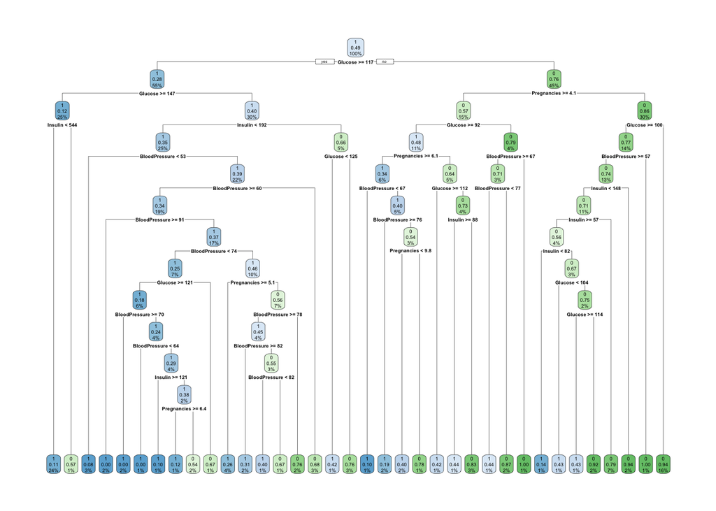

### Addressing the Disadvantages of Decision Trees

The decision trees have decent accuracy rates, however they suffer from unavoidable disadvantages. First, they have many levels (more than a dozen), and can be hard or unwieldy to use. Also, due to its large size, there are probably repeating decision nodes; if one needs adjustment, there are multiple places to do so. Lastly, one can guess these decision trees are overfitted and sensitive to the data. If any previously unforeseen data appears, the decision trees may not predict properly.

To combat this issues, we can prune both decision trees by removing levels. For decision tree #1, we’ll prune the tree back and remove levels. For the second tree, we’ll retrain the model but add a max depth parameter to control its growth.

### Post-pruning Decision Tree #1

We’ll use the plotcp & printcp functions to see how the relative errors progress as more levels are added. When the error comes close to 0.6, the tree can be stopped. In this case, that happens when the complexity parameter is 0.0330189.

We’ll apply this parameter to the previous model and end up with a simpler decision tree.

At the end, the accuracy definitely drops but we end up with a much more understandable tree.

### Finding an ideal cost parameter (cp)

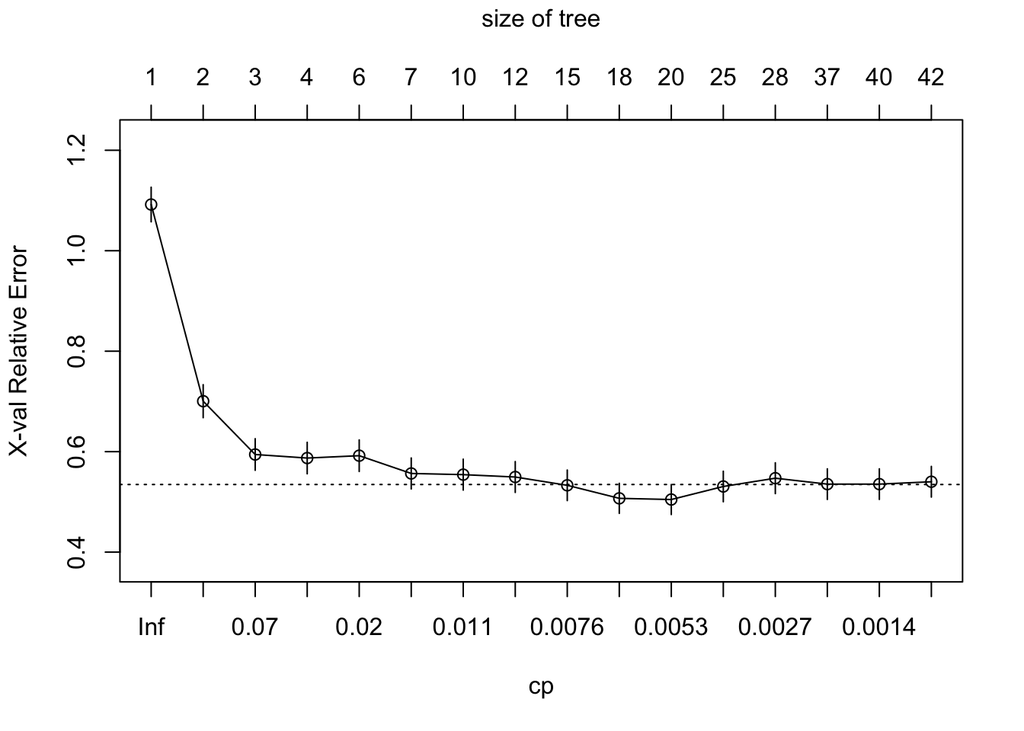

We see the cost parameter (bottom axis) coming close to the relative error level of below 0.6.

```
##
## Classification tree:
## rpart(formula = Outcome ~ Age + DiabetesPedigreeFunction + BMI +
##     SkinThickness, data = data_train, method = "class", control = rpart.control(cp = 0))
##
## Variables actually used in tree construction:
## [1] Age                      BMI                      DiabetesPedigreeFunction
## [4] SkinThickness
##
## Root node error: 424/858 = 0.49417
##
## n= 858
##
##           CP nsplit rel error  xerror     xstd
## 1  0.3066038      0   1.00000 1.09198 0.034433
## 2  0.1155660      1   0.69340 0.70047 0.032866
## 3  0.0424528      2   0.57783 0.59434 0.031465
## 4  0.0235849      3   0.53538 0.58726 0.031354
## 5  0.0165094      5   0.48821 0.59198 0.031428
## 6  0.0117925      6   0.47170 0.55660 0.030849
## 7  0.0094340      9   0.43632 0.55425 0.030808
## 8  0.0082547     11   0.41745 0.54953 0.030726
## 9  0.0070755     14   0.39151 0.53302 0.030430
## 10 0.0058962     17   0.37028 0.50708 0.029937
## 11 0.0047170     19   0.35849 0.50472 0.029891
## 12 0.0031447     24   0.33491 0.53066 0.030387
## 13 0.0023585     27   0.32547 0.54717 0.030685
## 14 0.0015723     36   0.30189 0.53538 0.030473
## 15 0.0011792     39   0.29717 0.53538 0.030473
## 16 0.0000000     41   0.29481 0.54009 0.030559
```

### Post prune Decision Tree #1

At the end, the accuracy doesn’t drop very much and we end up with a much more digestable tree.

```r
diabetes_model_1_pruned <- prune(diabetes_model_1, cp = 0.0330189 )

diabetes_pred_1 <- predict(diabetes_model_1_pruned, data_test, type="class")
c <- confusionMatrix(diabetes_pred_1, data_test$Outcome)
c$overall[1]
```

```
##  Accuracy
## 0.6915888
```

```r
c$table
```

```
##           Reference
## Prediction  1  0
##          1 85 49
##          0 17 63
```

```r
diabetes_prune_1_accuracy <- round(c$overall[[1]], 2)
```

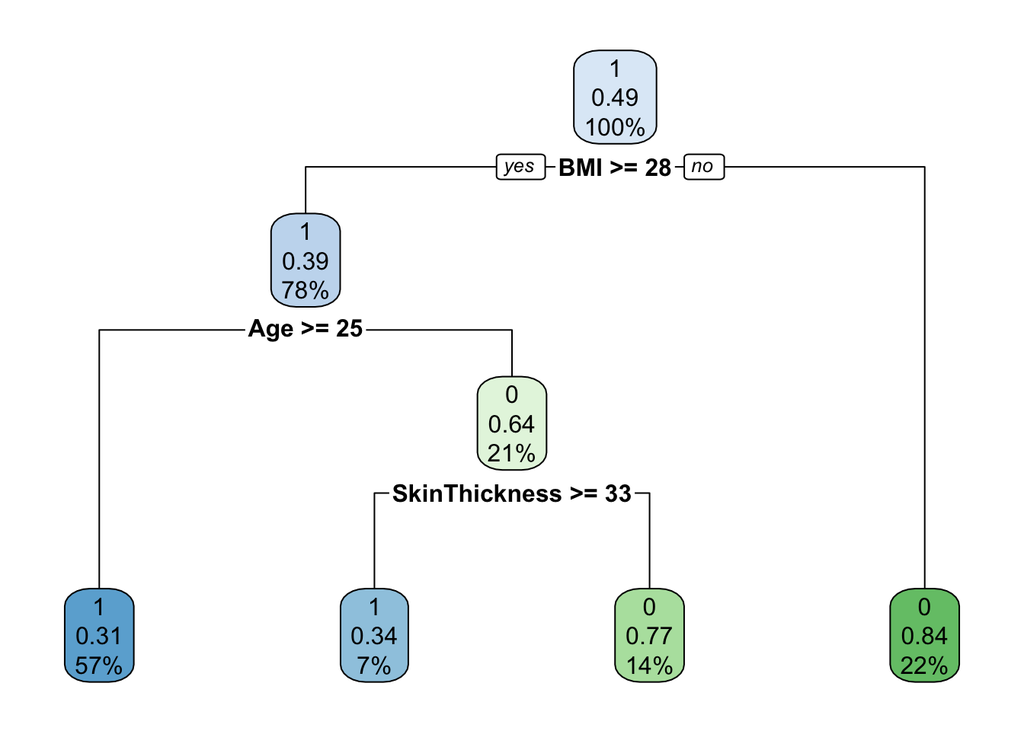

### Post Pruning Decision Tree #2

For the second tree, we’ll observe the cost parameter plot and see what the max depth should be. The diagram shows a depth of 3 is where the relative error levels off.

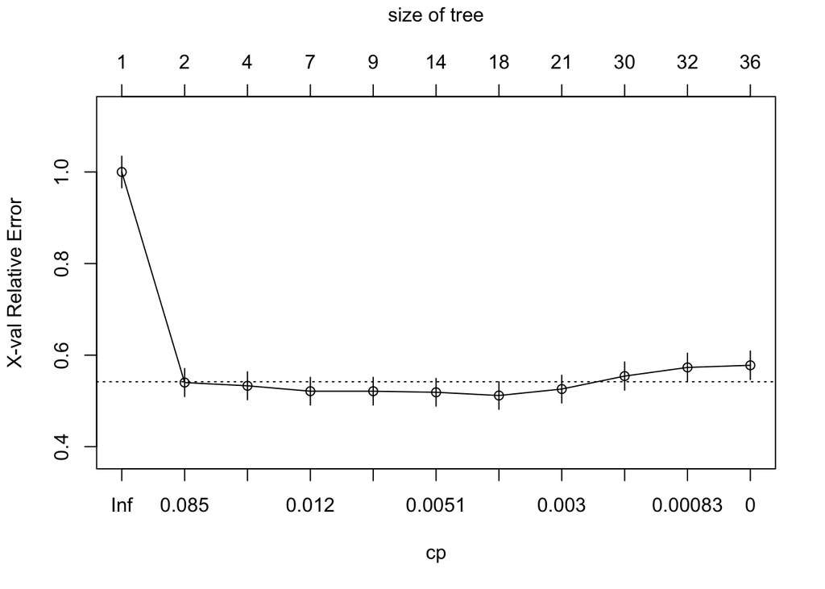

We’ll recreate the second tree and specify the **maxdepth to equal 3**.

```r
diabetes_model_2 <- rpart(Outcome ~Pregnancies+Glucose+BloodPressure+Insulin,
                          method="class",
                          data = data_train,
                          control = rpart.control(cp = 0, maxdepth=3)
                          )

diabetes_pred_2 <- predict(diabetes_model_2, data_test, type="class")
c <- confusionMatrix(diabetes_pred_2, data_test$Outcome)
paste0("Decision Tree 2")
```

```
## [1] "Decision Tree 2"
```

```r
c$overall[1]
```

```
##  Accuracy
## 0.7149533
```

```r
c$table
```

```
##           Reference
## Prediction  1  0
##          1 82 41
##          0 20 71
```

```r
diabetes_prune_2_accuracy <- round(c$overall[[1]], 2)
```

Rebuilding the second model and a max depth of 3 results in an accuracy of 71% with the below tree. Again, the accuracy loss is relatively low compared to the improvement in the decision tree.

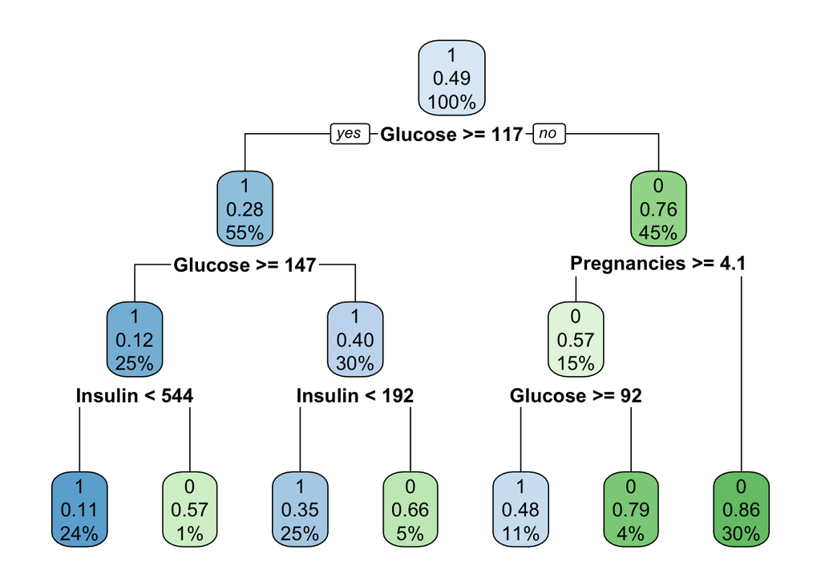

### Random Forest Model

The last model we’ll build is a random forest. Using default values, the random forest model has a 90% accuracy rate with 500 sub trees. Notice, we cannot improve the sub trees or even print them. It doesn’t make sense in this case as random forests are ensemble learners and no single tree dominates. Instead, each tree has random predictors and their scores are weighted so only the whole is important.

```
##  Accuracy
## 0.8925234
```

```
##           Reference
## Prediction   1   0
##          1  91  12
##          0  11 100
```

```r
rf
```

```
##
## Call:
##  randomForest(formula = Outcome ~ ., data = data_train)
##                Type of random forest: classification
##                      Number of trees: 500
## No. of variables tried at each split: 2
##
##         OOB estimate of  error rate: 11.19%
## Confusion matrix:
##     1   0 class.error
## 1 392  42  0.09677419
## 0  54 370  0.12735849
```

### Comparing Accuracy Rates

To help compare their performances, we can look at a chart of the random forest versus the first two decision trees. Even though the basic decision trees perform worse, the random forest uses these simpler trees to build a better model.

[output not shown]

# ROC Curves for the Decision Trees and Random Forest Model

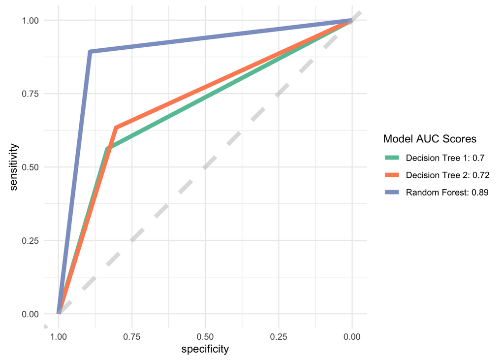

### Last Remarks

Again, when using individual trees, we can inspect their internal logic structure and understand where their weakpoints are. We can also grasp how the training data would directly affect their node structure, also. And we can limit how many levels are in a tree to simplify them with as long as the sacrifice in accuracy is acceptable.

On the other hand, we see how an ensembler learner like a random forest model that uses multiple simple trees can take subsets of predictors and trees and producer a model with a higher accuracy. However, we no longer have access to its internal logic and any attempts to audit or confirm its operation will not be easy.